# PEC1_Datos_Omicos

Raul

2024-11-06

```r
install.packages("readxl")
if (!requireNamespace("BiocManager", quietly = TRUE))
    install.packages("BiocManager")
BiocManager::install("SummarizedExperiment")
```

# Abstract

```r
# Cargar las librerías
library(readxl)
library(SummarizedExperiment)
```

# Objetivos del Estudio

El objetivo principal de este trabajo es realizar un análisis exploratorio de unos datos de metabolomica, descargados de un repositorio github, utilizando el programa estadístico R y las librerías para análisis de datos ómicos integradas en Bioconductor.

Como objetivos específicos podemos señalar los siguientes:

1. Identificar un conjunto de datos (“dataset”) de interés en la tabla proporcionada y descargarlo para crear, un objeto de clase SummarizedExperiment con los datos de expresión y sus meta-datos.
2. Llevar a cabo un análisis exploratorio de los datos que proporcionar una visión general de las variables y de los individuos.

# *Materiales y Métodos*

Es recomendable evaluar la calidad de los datos y eliminar cualquier metabolito que esté mal medido antes de realizar análisis estadísticos o aplicar modelos de aprendizaje automático (Broadhurst et al., 2018). En el caso del conjunto de datos de Cáncer Gástrico por RMN utilizado en este ejemplo, ya hemos calculado algunas estadísticas básicas para cada metabolito, las cuales se encuentran registradas en la tabla Peak. En este cuaderno, solo se mantendrán los metabolitos que cumplan con los siguientes requisitos:

Un QC-RSD inferior al 20% Menos del 10% de los valores están ausentes Una vez que los datos sean depurados, se indicará la cantidad de picos que quedan.

```r
# Leer las hojas del archivo Excel

file_path <- "GastricCancer_NMR.xlsx"
data_df <- read_excel(file_path, sheet = "Data")
metabolites_df <- read_excel(file_path, sheet = "Peak")
```

```r
# Filtrar las muestras para eliminar las que tienen SampleType = "QC"
data_df <- data_df[data_df$SampleType != "QC", ]
```

```r
# Extraer la matriz de datos de las columnas que empiezan con 'M'
metabolite_columns <- grep("^M", names(data_df), value = TRUE)
data_matrix <- as.matrix(data_df[, metabolite_columns])
```

```r
# Transponer la matriz para que las muestras estén en las columnas
data_matrix <- t(data_matrix)
```

```r
# Crear los metadatos de las muestras (SampleID, SampleType, Class) después del filtrado
colData <- DataFrame(
    SampleID = data_df$SampleID,
    SampleType = data_df$SampleType,
    Class = data_df$Class
)
```

```r
# Crear los metadatos de los metabolitos (Name, Label)
rowData <- DataFrame(
    Name = metabolites_df$Name,
    Label = metabolites_df$Label,
    Perc_missing = metabolites_df$Perc_missing,
    QC_RSD = metabolites_df$QC_RSD
)
```

```r
# Crear el objeto SummarizedExperiment
se <- SummarizedExperiment(
    assays = list(counts = data_matrix),
    rowData = rowData,
    colData = colData,
    metadata = list(
        description = "Columns M1 ... M149 describe metabolite concentrations. Column SampleType indicates whether the sample was a pooled QC or a study sample. Column Class indicates the clinical outcome observed for that individual: GC = Gastric Cancer, BN = Benign Tumor, HE = Healthy Control."
    )
)
```

```r
# Filtrar los metabolitos según los criterios de calidad
se_filtered <- se[
  rowData(se)$Perc_missing < 10 & rowData(se)$QC_RSD < 20,
  ]
```

```r
# Mostrar el objeto
print(se_filtered)
```

```
## class: SummarizedExperiment
## dim: 52 123
## metadata(1): description
## assays(1): counts
## rownames(52): M4 M5 ... M148 M149
## rowData names(4): Name Label Perc_missing QC_RSD
## colnames: NULL
## colData names(3): SampleID SampleType Class
```

# *Resultados*

## Estructura de los datos y del estudio

## 1. Análisis Descriptivo Inicial

```r
# Cargar las librerías necesarias
library(SummarizedExperiment)
library(ggplot2)
```

## 2. Visualización de Datos

## 3. Análisis de Variabilidad y Control de Calidad

1. Análisis de Varianza (ANOVA) o Test de Bartlett: Comparar la variabilidad de los metabolitos entre grupos (p. ej., control sano, tumor benigno, cáncer gástrico) para evaluar diferencias significativas en la dispersión.

```r
# Extraer la matriz de datos y la información de los grupos
data_matrix <- assay(se_filtered, "counts")
class_labels <- colData(se_filtered)$Class
```

```r
# Aplicar el Test de Bartlett a cada metabolito
bartlett_results <- apply(data_matrix, 1, function(x) {
  bartlett.test(x ~ class_labels)$p.value
})

# Mostrar los resultados de los primeros 10 metabolitos
bartlett_results_df <- data.frame(
  Metabolite = rownames(data_matrix),
  P_Value = bartlett_results
)
print(bartlett_results_df)
```

```
##      Metabolite      P_Value
## M4           M4 4.224673e-07
## M5           M5 2.427859e-07
## M7           M7 4.324870e-05
## M8           M8 3.259681e-05
## M11         M11 8.126121e-09
## M14         M14 1.526602e-02
## M15         M15 2.570469e-01
## M25         M25 2.987421e-06
## M26         M26 6.198063e-20
## M31         M31 1.427729e-07
## M32         M32 1.907688e-07
## M33         M33 3.845738e-03
## M36         M36 2.108317e-01
## M37         M37 9.197993e-08
## M45         M45 6.224370e-03
## M48         M48 8.383434e-03
## M50         M50 5.699905e-47
## M51         M51 1.054609e-14
## M65         M65 1.640653e-02
## M66         M66 3.558642e-12
## M68         M68 1.967239e-06
## M71         M71 6.204509e-07
## M73         M73 2.129246e-01
## M74         M74 3.653292e-02
## M75         M75 1.490430e-04
## M88         M88 1.859847e-01
## M89         M89 4.384363e-12
## M90         M90 1.782541e-03
## M91         M91 4.335689e-03
## M93         M93 2.492443e-05
## M101       M101 2.014675e-02
## M104       M104 5.701262e-02
## M105       M105 1.201645e-04
## M106       M106 1.100085e-03
## M107       M107 1.610330e-01
## M110       M110 1.067979e-01
## M115       M115 7.156591e-11
## M116       M116 5.761903e-07
## M118       M118 1.546278e-12
## M119       M119 1.574691e-01
## M120       M120 4.857938e-06
## M122       M122 1.166833e-03
## M126       M126 1.025456e-21
## M129       M129 1.701761e-06
## M130       M130 2.870331e-11
## M134       M134 4.764165e-12
## M137       M137 2.922963e-02
## M138       M138 3.216760e-08
## M142       M142 2.185937e-09
## M144       M144 9.158809e-60
## M148       M148 9.873685e-02
## M149       M149 3.158070e-01
```

Interpretación: Si un p-valor es menor que 0.05, sugiere que hay una diferencia significativa en la variabilidad de ese metabolito entre los grupos.

```r
# Aplicar ANOVA a cada metabolito
anova_results <- apply(data_matrix, 1, function(x) {
  summary(aov(x ~ class_labels))[[1]][["Pr(>F)"]][1]
})

# Mostrar los resultados de los primeros 10 metabolitos
anova_results_df <- data.frame(
  Metabolite = rownames(data_matrix),
  P_Value = anova_results
)
print(anova_results_df)
```

```
##      Metabolite      P_Value
## M4           M4 2.926107e-03
## M5           M5 3.175123e-01
## M7           M7 5.760973e-03
## M8           M8 1.222709e-01
## M11         M11 6.220643e-01
## M14         M14 2.888005e-01
## M15         M15 8.900031e-01
## M25         M25 1.103668e-01
## M26         M26 1.260561e-01
## M31         M31 6.153650e-01
## M32         M32 7.122914e-03
## M33         M33 4.229971e-01
## M36         M36 6.373565e-01
## M37         M37 5.086230e-01
## M45         M45 2.232977e-03
## M48         M48 1.482196e-01
## M50         M50 4.641730e-01
## M51         M51 1.572472e-01
## M65         M65 1.868775e-01
## M66         M66 1.375558e-01
## M68         M68 3.670154e-01
## M71         M71 6.506552e-01
## M73         M73 1.249217e-01
## M74         M74 7.358403e-01
## M75         M75 2.083039e-01
## M88         M88 5.486211e-01
## M89         M89 1.570093e-03
## M90         M90 2.750177e-01
## M91         M91 1.016169e-01
## M93         M93 2.709336e-01
## M101       M101 7.280050e-01
## M104       M104 2.620641e-01
## M105       M105 4.351292e-01
## M106       M106 4.583989e-01
## M107       M107 9.029112e-01
## M110       M110 4.764870e-01
## M115       M115 1.965663e-01
## M116       M116 3.122889e-01
## M118       M118 6.206694e-04
## M119       M119 6.760862e-01
## M120       M120 6.842801e-01
## M122       M122 7.415736e-01
## M126       M126 1.020387e-02
## M129       M129 4.528492e-01
## M130       M130 3.862113e-01
## M134       M134 5.641083e-04
## M137       M137 8.660670e-01
## M138       M138 4.078888e-05
## M142       M142 1.110574e-01
## M144       M144 3.438253e-01
## M148       M148 3.601856e-01
## M149       M149 2.819257e-01
```

Un p-valor bajo (< 0.05) indica diferencias significativas en las medias de las concentraciones entre los grupos

2. PCA (Análisis de Componentes Principales):
- Realizar un PCA para visualizar la separación global entre las clases (GC, BN, HE) y evaluar la presencia de agrupamientos claros o patrones.
- Este paso también ayuda a identificar la necesidad de normalización adicional si hay un sesgo por efecto de lote o variabilidad técnica.

El PCA se usa para reducir la dimensionalidad de los datos y visualizar cómo se agrupan las muestras según los metabolitos.

```r
# Función para imputar valores faltantes con la mediana de cada fila (metabolito)
data_matrix <- assay(se_filtered, "counts")
data_matrix <- apply(data_matrix, 1, function(x) {
  x[is.na(x) | is.infinite(x)] <- median(x, na.rm = TRUE)
  return(x)
})
data_matrix <- t(data_matrix)  # Transponer nuevamente para mantener la forma original
```

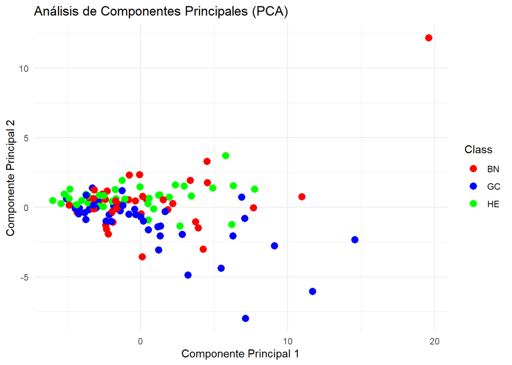

```r
# Cargar la librería para el PCA
library(ggplot2)

# Transponer la matriz de datos para que las muestras sean filas y los metabolitos columnas
pca_data <- t(data_matrix)

# Realizar el PCA
pca_result <- prcomp(pca_data, scale. = TRUE)  # scale. = TRUE para normalizar los datos

# Crear un data frame con los resultados del PCA
pca_df <- data.frame(
  PC1 = pca_result$x[, 1],
  PC2 = pca_result$x[, 2],
  Class = class_labels
)

# Graficar el PCA
ggplot(pca_df, aes(x = PC1, y = PC2, color = Class)) +
  geom_point(size = 3) +
  theme_minimal() +
  labs(
    title = "Análisis de Componentes Principales (PCA)",
    x = "Componente Principal 1",
    y = "Componente Principal 2"
  ) +
  scale_color_manual(values = c("red", "blue", "green"))  # Ajusta los colores según tus grupos
```

## Análisis Univariado Compararemos las concentraciones de cada metabolito entre las clases utilizando la prueba de t de Student o la prueba de Mann-Whitney U. Luego, aplicaremos una corrección por múltiples comparaciones

```r
install.packages("dplyr")
```

```r
library(dplyr)
# Extraer los datos
data_matrix <- assay(se_filtered, "counts")
class_labels <- colData(se_filtered)$Class

# Inicializar un data frame para almacenar los resultados
results <- data.frame(Metabolite = rownames(data_matrix), p_GC_HE = NA, p_GC_BN = NA)

# Realizar las comparaciones entre grupos
for (i in 1:nrow(data_matrix)) {
  # Extraer concentraciones del metabolito actual
  metabolite_data <- data_matrix[i, ]

  # Comparación entre GC y HE
  results$p_GC_HE[i] <- wilcox.test(metabolite_data[class_labels == "GC"],
                                     metabolite_data[class_labels == "HE"])$p.value

  # Comparación entre GC y BN
  results$p_GC_BN[i] <- wilcox.test(metabolite_data[class_labels == "GC"],
                                     metabolite_data[class_labels == "BN"])$p.value
}

# Aplicar corrección por múltiples comparaciones (FDR de Benjamini-Hochberg)
results <- results %>%
  mutate(
    p_adj_GC_HE = p.adjust(p_GC_HE, method = "BH"),
    p_adj_GC_BN = p.adjust(p_GC_BN, method = "BH")
  )

# Mostrar los primeros resultados
print(results)
```

```
##    Metabolite      p_GC_HE      p_GC_BN  p_adj_GC_HE p_adj_GC_BN
## 1          M4 4.229112e-03 0.0008962928 2.848735e-02  0.04660722
## 2          M5 3.026708e-01 0.7946699775 5.952753e-01  0.96708271
## 3          M7 4.901039e-03 0.0239424072 2.848735e-02  0.33621232
## 4          M8 4.900314e-02 0.0258624863 1.592602e-01  0.33621232
## 5         M11 7.325709e-01 0.7109812185 9.037709e-01  0.96096604
## 6         M14 1.380516e-01 0.0688759505 3.778253e-01  0.51164992
## 7         M15 6.717219e-01 0.2254644232 9.037709e-01  0.68965588
## 8         M25 7.629027e-02 0.6258443649 2.333585e-01  0.95717373
## 9         M26 2.331754e-01 0.9283069739 5.271791e-01  0.99638411
## 10        M31 9.781868e-01 0.7207245276 9.973670e-01  0.96096604
## 11        M32 4.930502e-03 0.1803395156 2.848735e-02  0.68912042
## 12        M33 5.464179e-01 0.9674657614 8.610221e-01  0.99638411
## 13        M36 2.614856e-01 0.6237016753 5.665522e-01  0.95717373
## 14        M37 9.636541e-01 0.5294535766 9.973670e-01  0.88811568
```

[output cut: 38 more lines]

Los valores ajustados (p_adj_GC_HE y p_adj_GC_BN) reflejan la significancia después de la corrección por múltiples comparaciones. Un valor ajustado bajo (< 0.05) sugiere una diferencia significativa entre los grupos para ese metabolito.

## Análisis de Significancia Biológica: Cálculo de Fold Change

```r
# Calcular fold change
results <- results %>%
  mutate(
    fold_change_GC_HE = apply(data_matrix, 1, function(x) {
      mean(x[class_labels == "GC"], na.rm = TRUE) / mean(x[class_labels == "HE"], na.rm = TRUE)
    }),
    fold_change_GC_BN = apply(data_matrix, 1, function(x) {
      mean(x[class_labels == "GC"], na.rm = TRUE) / mean(x[class_labels == "BN"], na.rm = TRUE)
    })
  )

# Mostrar los primeros resultados
print(results)
```

```
##    Metabolite      p_GC_HE      p_GC_BN  p_adj_GC_HE p_adj_GC_BN
## 1          M4 4.229112e-03 0.0008962928 2.848735e-02  0.04660722
## 2          M5 3.026708e-01 0.7946699775 5.952753e-01  0.96708271
## 3          M7 4.901039e-03 0.0239424072 2.848735e-02  0.33621232
## 4          M8 4.900314e-02 0.0258624863 1.592602e-01  0.33621232
## 5         M11 7.325709e-01 0.7109812185 9.037709e-01  0.96096604
## 6         M14 1.380516e-01 0.0688759505 3.778253e-01  0.51164992
## 7         M15 6.717219e-01 0.2254644232 9.037709e-01  0.68965588
## 8         M25 7.629027e-02 0.6258443649 2.333585e-01  0.95717373
## 9         M26 2.331754e-01 0.9283069739 5.271791e-01  0.99638411
## 10        M31 9.781868e-01 0.7207245276 9.973670e-01  0.96096604
## 11        M32 4.930502e-03 0.1803395156 2.848735e-02  0.68912042
## 12        M33 5.464179e-01 0.9674657614 8.610221e-01  0.99638411
## 13        M36 2.614856e-01 0.6237016753 5.665522e-01  0.95717373
## 14        M37 9.636541e-01 0.5294535766 9.973670e-01  0.88811568
```

[output cut: 91 more lines]

Interpretación: Un “fold change” mayor que 1 indica que el metabolito es más abundante en el grupo GC en comparación con HE o BN, mientras que un valor menor que 1 indica menor abundancia en GC.

## Analisis Multivariado

1. PLS-DA (Partial Least Squares Discriminant Analysis)

```r
# Instala mixOmics si no lo tienes
if (!requireNamespace("BiocManager", quietly = TRUE))
    install.packages("BiocManager")
BiocManager::install("mixOmics")
library(mixOmics)
```

COnfiguramos los datos para PLS-DA

```r
# Extraer la matriz de datos y etiquetas de clase
data_matrix <- t(assay(se_filtered, "counts"))  # Transponer para que las muestras sean filas
class_labels <- colData(se_filtered)$Class

# Convertir las etiquetas de clase a un factor
class_labels <- as.factor(class_labels)
```

Ralizamos el PLS

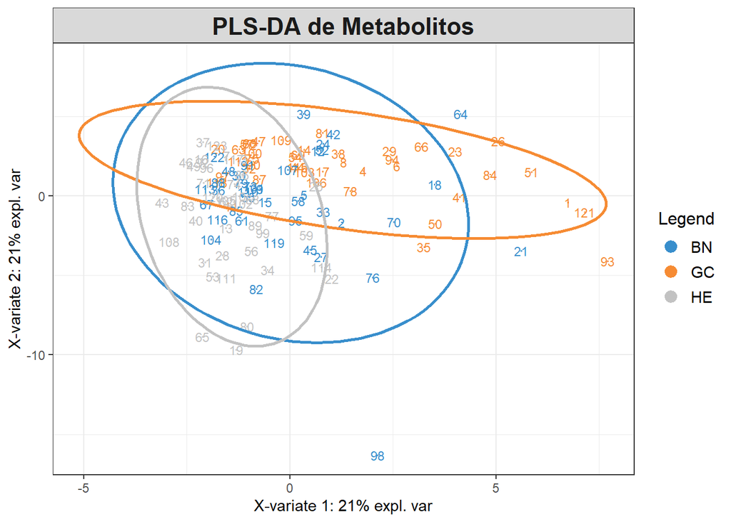

```r
# Ejecutar PLS-DA
plsda_result <- plsda(X = data_matrix, Y = class_labels, ncomp = 2)  # ncomp = 2 componentes

# Graficar el PLS-DA
plotIndiv(plsda_result, group = class_labels, legend = TRUE,
          title = "PLS-DA de Metabolitos", ellipse = TRUE, comp = c(1, 2))
```

Interpretación: plotIndiv muestra la discriminación entre clases. Si el PLS-DA separa bien los grupos, debería haber una clara diferencia en el gráfico.

Evaluar la Robustez del Modelo con Validación Cruzad

```r
# Validación cruzada con mixOmics
set.seed(625745221)  # Para reproducibilidad
cv_result <- perf(plsda_result, validation = "Mfold", folds = 5, progressBar = TRUE, nrepeat = 10)
```

[output not shown]

```r
# Ver resultados de validación cruzada
print(cv_result)
```

```
##
## Call:
##  perf.mixo_plsda(object = plsda_result, validation = "Mfold", folds = 5, nrepeat = 10, progressBar = TRUE)
##
##  Main numerical outputs:
##  --------------------
##  Error rate (overall or BER) for each component and for each distance: see object$error.rate
##  Error rate per class, for each component and for each distance: see object$error.rate.class
##  Prediction values for each component: see object$predict
##  Classification of each sample, for each component and for each distance: see object$class
##  AUC values: see object$auc if auc = TRUE
##
##  Visualisation Functions:
##  --------------------
##  plot
```

error rate

```r
# Ver tasa de error
print(cv_result$error.rate)
```

```
## $overall
##        max.dist centroids.dist mahalanobis.dist
## comp1 0.5243902      0.5382114        0.5382114
## comp2 0.4130081      0.4601626        0.4219512
##
## $BER
##        max.dist centroids.dist mahalanobis.dist
## comp1 0.5276163      0.5375388        0.5375388
## comp2 0.4192636      0.4642829        0.4251744
```

Error rate por clase

```r
# Tasa de error por clase
print(cv_result$error.rate.class)
```

```
## $max.dist
##        comp1     comp2
## BN 1.0000000 0.9300000
## GC 0.3953488 0.1627907
## HE 0.1875000 0.1650000
##
## $centroids.dist
##        comp1     comp2
## BN 0.7375000 0.6200000
## GC 0.5651163 0.2953488
## HE 0.3100000 0.4775000
##
## $mahalanobis.dist
##        comp1     comp2
## BN 0.7375000 0.6725000
## GC 0.5651163 0.2930233
## HE 0.3100000 0.3100000
```

Validación Cruzada: El resultado de la validación cruzada (cv_result) ayuda a verificar si el modelo es robusto y no sobreajustado.

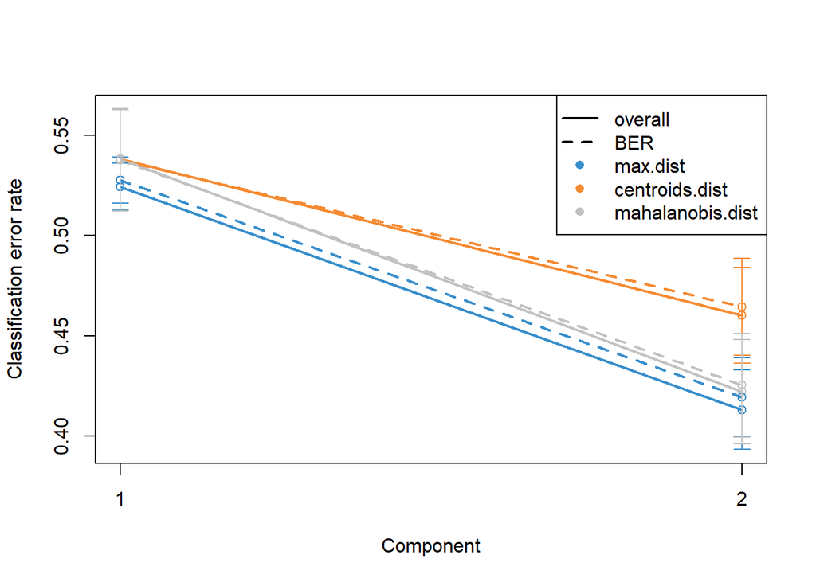

```r
# Graficar resultados de validación cruzada
plot(cv_result)
```

Esto generará gráficos que te permiten ver cómo varía el error con el número de componentes, lo cual es útil para decidir cuántos componentes incluir en el modelo PLS-DA final.

Analizar las Cargas (Loadings) para Identificar Metabolitos Relevantes

```r
# Extraer y visualizar las cargas para interpretar los metabolitos que más contribuyen
loadings <- plsda_result$loadings$X  # Cargas para las variables

# Mostrar los primeros metabolitos relevantes
top_metabolites <- rownames(loadings)[order(abs(loadings[, 1]), decreasing = TRUE)[1:10]]
print(top_metabolites)
```

```
##  [1] "M138" "M134" "M118" "M45"  "M89"  "M32"  "M7"   "M126" "M4"   "M91"
```

```r
# Crear un data frame con IDs y Labels de los metabolitos en rowData
metabolite_info <- data.frame(
  ID = rownames(rowData(se_filtered)),
  Label = rowData(se_filtered)$Label
)

# Filtrar para obtener solo los metabolitos en top_metabolites y asegurar el orden correcto
top_metabolite_info <- metabolite_info[match(top_metabolites, metabolite_info$ID), ]

# Mostrar los resultados correctamente alineados
print(top_metabolite_info)
```

```
##      ID                       Label
## 48 M138                        u233
## 46 M134                        u144
## 39 M118                     Tropate
## 15  M45                     Citrate
## 27  M89 N-AcetylglutamineDerivative
## 11  M32                     Alanine
## 3    M7             2-Furoylglycine
## 43 M126             trans-Aconitate
## 1    M4        1-Methylnicotinamide
## 29  M91           N-Acetylserotonin
```

# *Discusión, Limitaciones y conclusiones del estudio*